# Análise exploratória dos dados.

## Há associação entre quantidade de palavras em capslock e a insatisfação?

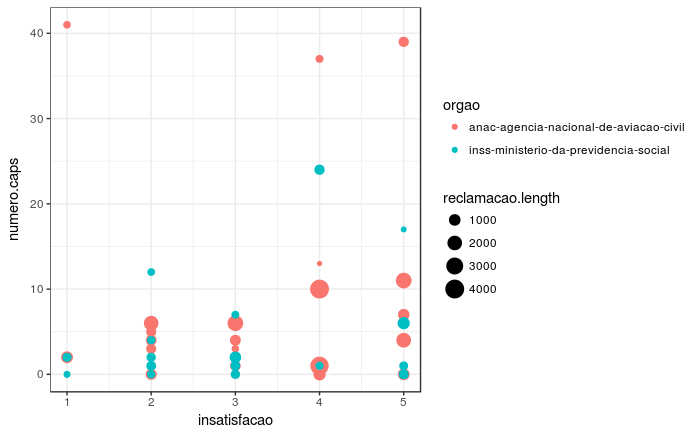

Pelo gráfico, notamos que geralmente reclamações com uma quantidade maior de palavras em caps possuem um nivel maior de instatisfação. Utilizando novamente a correlação para medir, temos:

```r
cor(reclamacoes$numero.caps, reclamacoes$insatisfacao, method = "pearson")
```

```
[1] 0.2331301
```

Por esse valor, podemos dizer que existe uma associação, mas que ela é fraca.

## Quantas reclamações temos para cada nível de insatisfação?

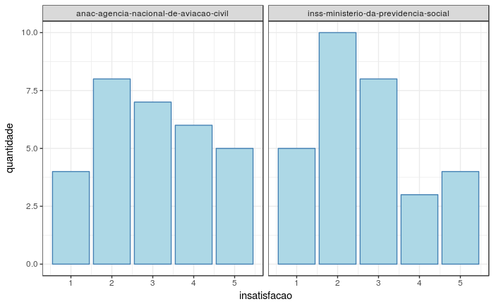

```r
avaliacoes %>%
    group_by(insatisfacao,
             orgao) %>%
    summarise(quantidade = n()) %>%
    ungroup() %>%
    ggplot(aes(x = insatisfacao,
               y = quantidade)) +
    geom_col(color = "#4682B4",
             fill = "#ADD8E6") +
    facet_grid(~ orgao)
```

Vemos que é baixa a quantidade de reclamações com um nível alto de instatisfação, e que a *ANAC* possui uma quantidade maior de reclamações com um nível mais alto de insatisfação.

## Como é o tamanho das reclamações de cada órgao?

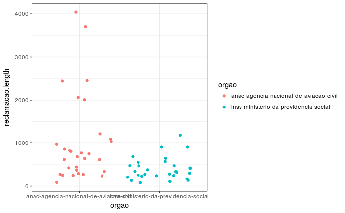

```r
reclamacoes %>%
    ggplot(aes(x = orgao,
               y = reclamacao.length,
               colour = orgao)) +
    geom_jitter()
```

Vemos que a maioria das reclamações dos dois órgãos estão numa faixa parecidade de tamanho, mas que a *ANAC* possui algumas reclações de maior tamanho.